# Reproducible Research: Peer Assessment 1

## Loading and preprocessing the data

```r
data <- read.csv("activity.csv")
str(data)
```

```
## 'data.frame':    17568 obs. of  3 variables:
##  $ steps   : int  NA NA NA NA NA NA NA NA NA NA ...
##  $ date    : chr  "2012-10-01" "2012-10-01" "2012-10-01" "2012-10-01" ...
##  $ interval: int  0 5 10 15 20 25 30 35 40 45 ...
```

## What is mean total number of steps taken per day?

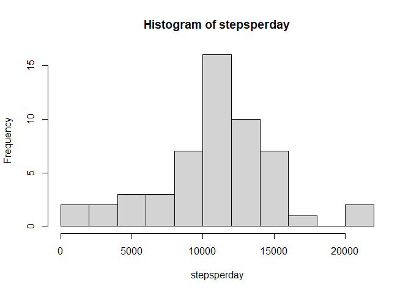

```r
stepsperday <- tapply(data$steps, data$date, sum)
hist(stepsperday, breaks = 10)
```

Mean of the total number of steps taken per day:

```r
mean1 <- mean(stepsperday, na.rm = T)
mean1
```

```
## [1] 10766.19
```

Median of the total number of steps taken per day:

```r
median1 <- median(stepsperday, na.rm = T)
median1
```

```
## [1] 10765
```

## What is the average daily activity pattern?

1. Make a time series plotof the 5-minute interval (x-axis) and the average number of steps taken, averaged across all days (y-axis)

```r
library(dplyr)
```

```r
avgsteps<-data %>% select(steps,interval) %>% group_by(interval) %>% summarise(average_steps = mean(steps, na.rm = T))
```

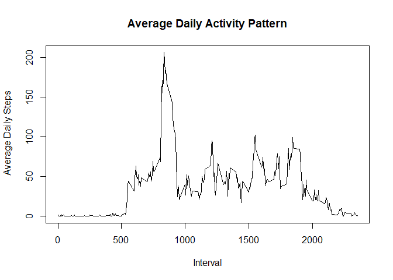

```r
plot(avgsteps$interval,avgsteps$average_steps, type = "l", xlab = "Interval", ylab = " Average Daily Steps", main = "Average Daily Activity Pattern")
```

2. Which 5-minute interval, on average across all the days in the dataset, contains the maximum number of steps?

```r
filter(avgsteps, average_steps == max(average_steps))
```

```
## # A tibble: 1 x 2
##   interval average_steps
##      <int>         <dbl>
## 1      835          206.
```

## Imputing missing values

```r
library(dplyr)
```

Checking how many missing values are there:

```r
colSums(is.na(data))
```

```
##    steps     date interval
##     2304        0        0
```

```r
data2<-data %>% group_by(interval) %>%
mutate(steps=ifelse(is.na(steps),mean(steps,na.rm=TRUE),steps))
```

Checking for missign values now:

```r
colSums(is.na(data2))
```

```
##    steps     date interval
##        0        0        0
```

Histogram of total number of steps per day

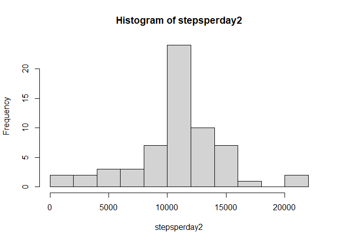

```r
stepsperday2 <- tapply(data2$steps, data2$date, sum)
hist(stepsperday2, breaks = 10)
```

Mean of the total number of steps taken per day:

```r
mean2 <- mean(stepsperday2, na.rm = T)
mean2
```

```
## [1] 10766.19
```

Median of the total number of steps taken per day:

```r
median2 <- median(stepsperday2, na.rm = T)
median2
```

```
## [1] 10766.19
```

Affects on the mean and median after imputing missing values:

Median before imputing: 10765

We can see that the mean remained exactly the same which is as expected because we used the mean by interval to replace the missing values. On the other hand theres a very small change in the median in fact mean and median are same now.

## Are there differences in activity patterns between weekdays and weekends?

```r
library(ggplot2)
```

Creating a new factor variable in the dataset with two levels – “weekday” and “weekend”

```r
data2$date <- as.Date(data2$date)
data2$week <- ifelse(weekdays(data2$date) %in% c("Saturday", "Sunday"), "weekend", "weekday")
```

Making a panel plot containing a time series plot of the 5-minute interval (x-axis) and the average number of steps taken, averaged across all weekday days or weekend days (y-axis).

```r
avgsteps2<-data2 %>% select(steps,interval, week) %>% group_by(interval,week) %>% summarise(average_steps = mean(steps, na.rm = T))
```

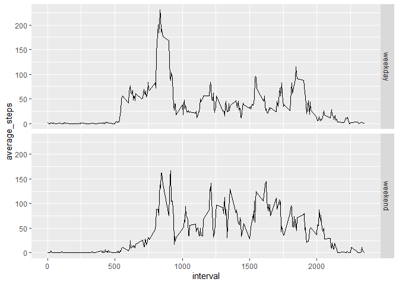

```r
p <- ggplot(avgsteps2, aes(x=interval, y=average_steps)) +
  geom_line() +
    facet_grid(week~.)
p
```